# assignment_qmao

Qing Mao

4/29/2020

## Executive Summary

Six young health participants were asked to perform one set of 10 repetitions of the Unilateral Dumbbell Biceps Curl in five different fashions: exactly according to the specification (Class A), throwing the elbows to the front (Class B), lifting the dumbbell only halfway (Class C), lowering the dumbbell only halfway (Class D) and throwing the hips to the front (Class E). Class A corresponds to the specified execution of the exercise, while the other 4 classes correspond to common mistakes.THe reacorded dataset is from http://web.archive.org/web/20161224072740/http:/groupware.les.inf.puc-rio.br/har. The goal of this analysis is to use training dataset to build a model that would be able to predict a given exercise whether it’s performed in the correct form.

## Report

### Load the data and explore only the training data

```r
training_data=read.csv("https://d396qusza40orc.cloudfront.net/predmachlearn/pml-training.csv")
testing_data=read.csv("https://d396qusza40orc.cloudfront.net/predmachlearn/pml-testing.csv")
```

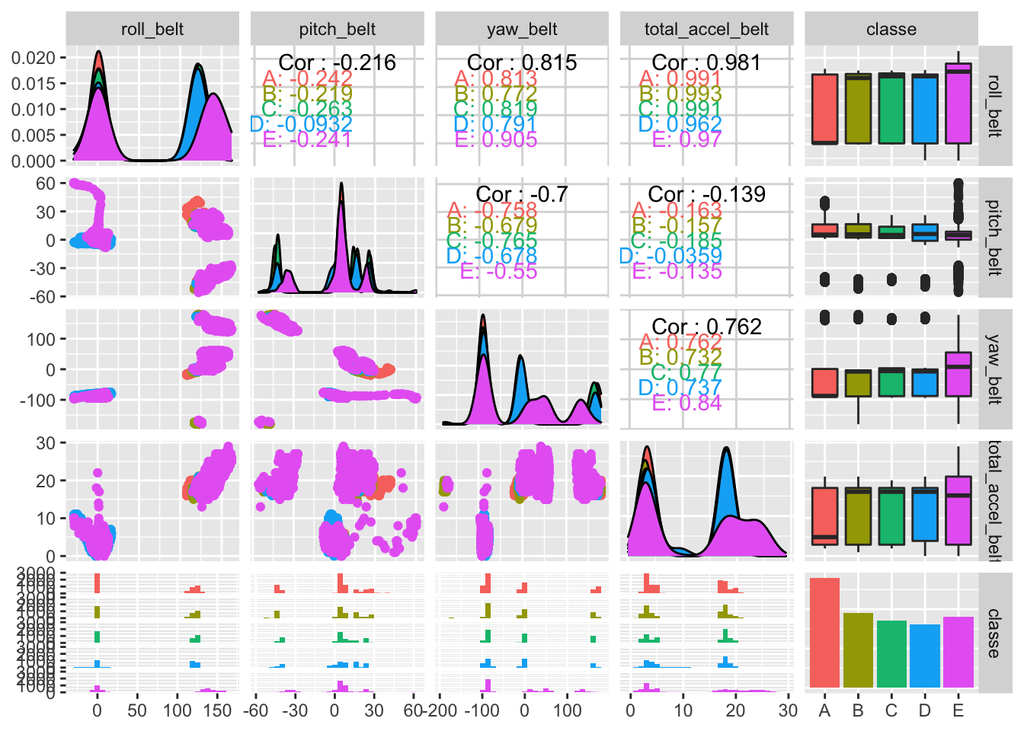

```r
#### exploratory on training data only ####
#### For rows with new_window=="yes", the measurements are a summary for that measurement window, and the summary measurements (average, sd, etc.) are only applicable to those rows, and most of the other rows are NAs. Thus remove those columns for future analysis.
training_select=subset(training_data,select=c(8:11,37:49,60:68,84:86,102,113:124,140,151:160))

ggpairs(training_select[,c(1:4,53)],aes(color=classe))
```

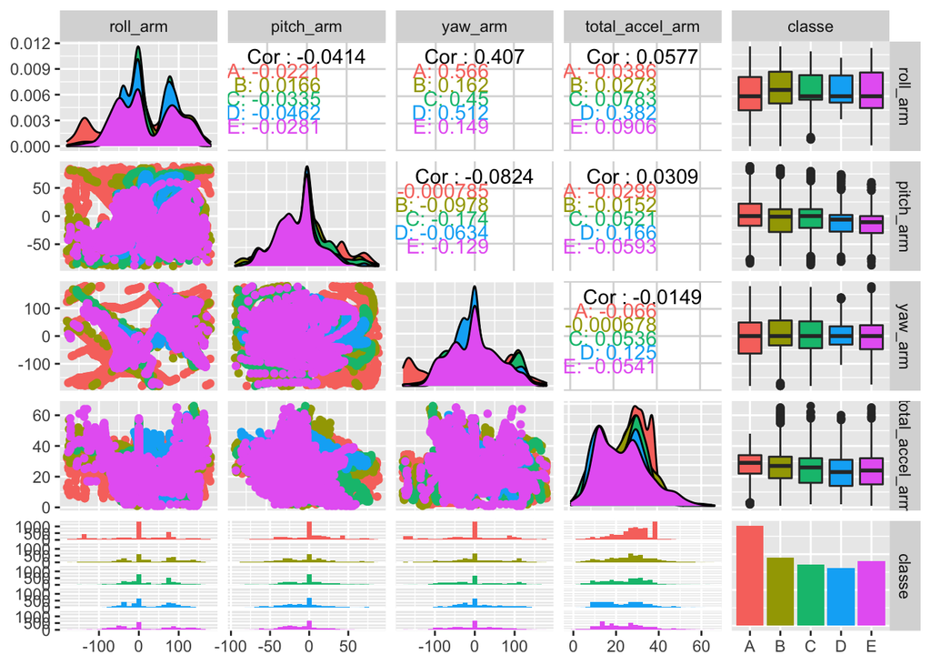

```r
ggpairs(training_select[,c(14:17,53)],aes(color=classe))
```

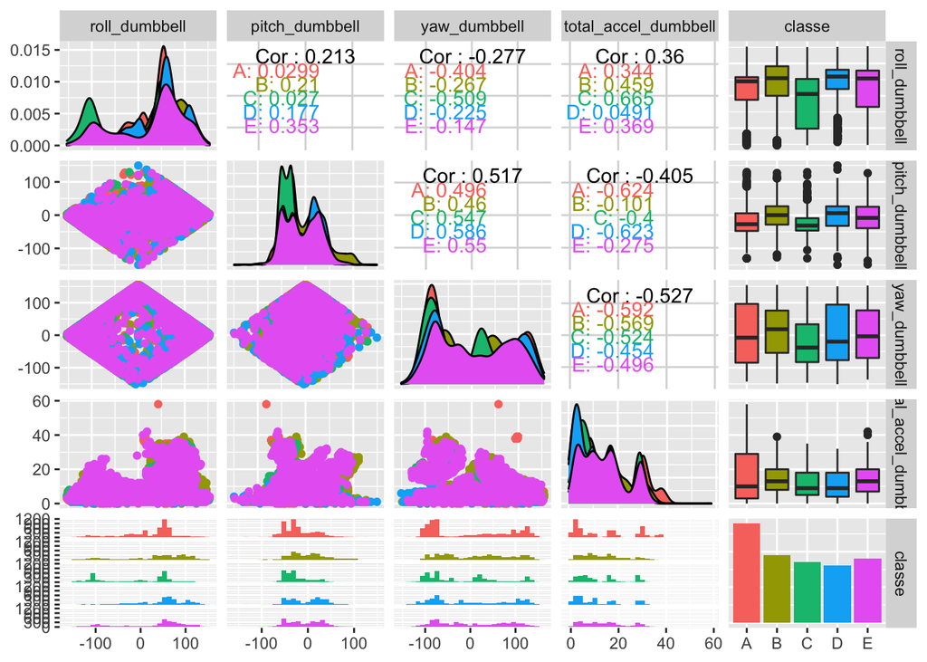

```r
ggpairs(training_select[,c(27:30,53)],aes(color=classe))
```

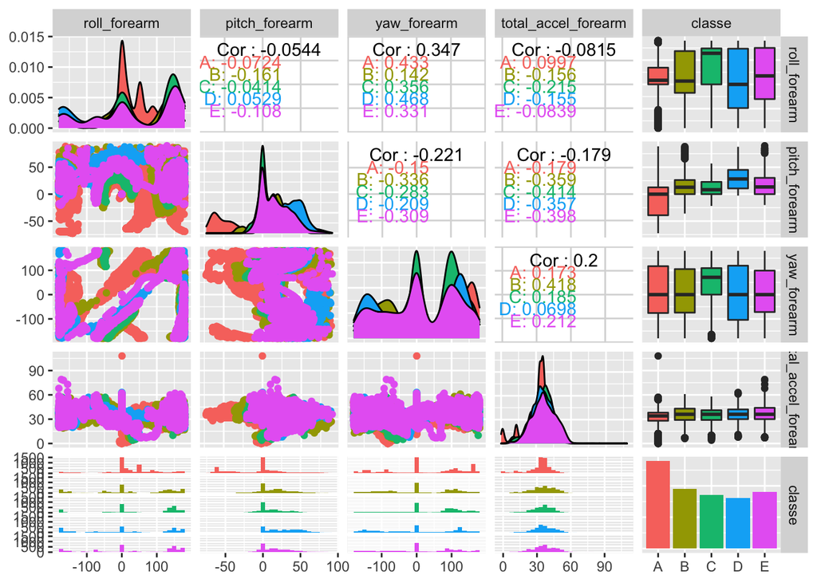

```r
ggpairs(training_select[,c(40:43,53)],aes(color=classe))
```

### Train prediction models and evaluate their performances. The Out of Sample error rate can be evaluated by applying the model on the testing dataset and calculate the accuracy. Because the data has a decent size, cross validation can be performed within the training data only.

```r
### in testing_data, the outcome column is not provided, but can be identified from the training data columns of username, timestamp
testing_data=merge(testing_data,unique(training_data[,c("user_name","raw_timestamp_part_1","cvtd_timestamp","num_window","classe")]),all.x=T)

### a combination of numerial predictors to predict a factor variable outcome
### test1: try randome forest, with cross validation
rf_model=train(classe~.,training_select,method="rpart",
              trControl=trainControl(method="cv",number=10),set.seed(123))
rf_predict_test=predict(rf_model,testing_data)
rf_accuracy=confusionMatrix(factor(testing_data$classe),rf_predict_test)
rf_accuracy
```

```
## Confusion Matrix and Statistics
##
##           Reference
## Prediction A B C D E
##          A 7 0 0 0 0
##          B 3 0 5 0 0
##          C 0 0 1 0 0
##          D 0 0 1 0 0
##          E 1 0 2 0 0
##
## Overall Statistics
##
##                Accuracy : 0.4
##                  95% CI : (0.1912, 0.6395)
##     No Information Rate : 0.55
##     P-Value [Acc > NIR] : 0.942
##
##                   Kappa : 0.2357
##
##  Mcnemar's Test P-Value : NA
##
## Statistics by Class:
##
##                      Class: A Class: B Class: C Class: D Class: E
## Sensitivity            0.6364       NA   0.1111       NA       NA
## Specificity            1.0000      0.6   1.0000     0.95     0.85
## Pos Pred Value         1.0000       NA   1.0000       NA       NA
## Neg Pred Value         0.6923       NA   0.5789       NA       NA
## Prevalence             0.5500      0.0   0.4500     0.00     0.00
## Detection Rate         0.3500      0.0   0.0500     0.00     0.00
## Detection Prevalence   0.3500      0.4   0.0500     0.05     0.15
## Balanced Accuracy      0.8182       NA   0.5556       NA       NA
```

```r
### test2: try lda
lda_model=train(classe~.,training_select,method="lda",
              trControl=trainControl(method="cv",number=10),set.seed(123))
lda_predict_test=predict(lda_model,testing_data)
lda_accuracy=confusionMatrix(factor(testing_data$classe),lda_predict_test)
lda_accuracy
```

```
## Confusion Matrix and Statistics
##
##           Reference
## Prediction A B C D E
##          A 5 0 2 0 0
##          B 0 6 0 2 0
##          C 1 0 0 0 0
##          D 0 0 0 1 0
##          E 1 0 0 0 2
##
## Overall Statistics
##
##                Accuracy : 0.7
##                  95% CI : (0.4572, 0.8811)
##     No Information Rate : 0.35
##     P-Value [Acc > NIR] : 0.001521
##
##                   Kappa : 0.589
##
##  Mcnemar's Test P-Value : NA
##
## Statistics by Class:
##
##                      Class: A Class: B Class: C Class: D Class: E
## Sensitivity            0.7143   1.0000   0.0000   0.3333   1.0000
## Specificity            0.8462   0.8571   0.9444   1.0000   0.9444
## Pos Pred Value         0.7143   0.7500   0.0000   1.0000   0.6667
## Neg Pred Value         0.8462   1.0000   0.8947   0.8947   1.0000
## Prevalence             0.3500   0.3000   0.1000   0.1500   0.1000
## Detection Rate         0.2500   0.3000   0.0000   0.0500   0.1000
## Detection Prevalence   0.3500   0.4000   0.0500   0.0500   0.1500
## Balanced Accuracy      0.7802   0.9286   0.4722   0.6667   0.9722
```

```r
### test3: gbm
gbm_model=train(classe~.,training_select,method="gbm",
              trControl=trainControl(method="cv",number=10),set.seed(123),
              verbose=FALSE)
gbm_predict_test=predict(gbm_model,testing_data)
gbm_accuracy=confusionMatrix(factor(testing_data$classe),gbm_predict_test)
gbm_accuracy
```

```
## Confusion Matrix and Statistics
##
##           Reference
## Prediction A B C D E
##          A 7 0 0 0 0
##          B 0 8 0 0 0
##          C 0 0 1 0 0
##          D 0 0 0 1 0
##          E 0 0 0 0 3
##
## Overall Statistics
##
##                Accuracy : 1
##                  95% CI : (0.8316, 1)
##     No Information Rate : 0.4
##     P-Value [Acc > NIR] : 1.1e-08
##
##                   Kappa : 1
##
##  Mcnemar's Test P-Value : NA
##
## Statistics by Class:
##
##                      Class: A Class: B Class: C Class: D Class: E
## Sensitivity              1.00      1.0     1.00     1.00     1.00
## Specificity              1.00      1.0     1.00     1.00     1.00
## Pos Pred Value           1.00      1.0     1.00     1.00     1.00
## Neg Pred Value           1.00      1.0     1.00     1.00     1.00
## Prevalence               0.35      0.4     0.05     0.05     0.15
## Detection Rate           0.35      0.4     0.05     0.05     0.15
## Detection Prevalence     0.35      0.4     0.05     0.05     0.15
## Balanced Accuracy        1.00      1.0     1.00     1.00     1.00
```

## Conclusion/Discussion

From the analysi above, with gbm modeling, the model was able to produce 100% accuracy with the given 20 testing data points.